# Department of Environment and Natural Resources — Office of the Secretary

# 10 The attached bureaus

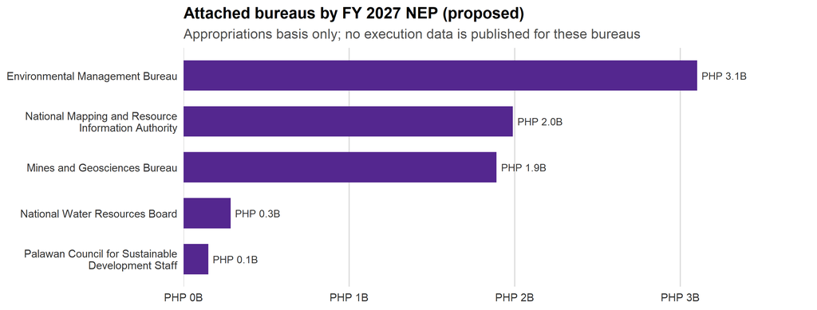

```r
attached <- df_long_all %>%
  filter(agency != "Office of the Secretary", expense_class == "TOTAL") %>%
  group_by(agency, year, metric) %>%
  summarise(amount = if (all(is.na(amount))) NA_real_ else sum(amount, na.rm = TRUE), .groups = "drop")

att_2027 <- attached %>% filter(metric == "NEP", year == 2027, !is.na(amount), amount > 0) %>%
  arrange(amount) %>% mutate(agency = factor(agency, levels = agency))

ggplot(att_2027, aes(agency, amount)) +
  geom_col(fill = "#54278F", width = 0.66) +
  geom_text(aes(label = php_b(amount)), hjust = -0.1, size = 3.2, color = "grey20") +
  coord_flip() +
  scale_x_discrete(labels = function(x) str_wrap(x, 40)) +
  scale_y_continuous(labels = php_b_axis, expand = expansion(mult = c(0, .22)), limits = c(0, NA)) +
  labs(title = "Attached bureaus by FY 2027 NEP (proposed)",
       subtitle = "Appropriations basis only; no execution data is published for these bureaus",
       x = NULL, y = NULL) +
  theme_denr() +
  theme(panel.grid.major.y = element_blank(), panel.grid.major.x = element_line(color = "grey85"))
```

```r
att_tbl <- attached %>%
  filter((metric == "NEP" & year %in% c(2026, 2027)) | (metric == "GAA" & year == 2026)) %>%
  mutate(key = paste0(metric, year)) %>%
  select(agency, key, amount) %>%
  pivot_wider(names_from = key, values_from = amount) %>%
  transmute(Bureau = agency,
            `NEP 2027 (B)` = NEP2027/1e9,
            `NEP 2026 (B)` = NEP2026/1e9,
            `GAA 2026 (B)` = GAA2026/1e9) %>%
  arrange(desc(`NEP 2027 (B)`))
kbl_clean(att_tbl, font = 13, digits = 2, format.args = list(big.mark = ","), na = "")
```

| Bureau | NEP 2027 (B) | NEP 2026 (B) | GAA 2026 (B) |
| --- | --- | --- | --- |
| Environmental Management Bureau | 3.10 | 3.31 | 3.46 |
| National Mapping and Resource Information Authority | 1.99 | 1.97 | 1.98 |
| Mines and Geosciences Bureau | 1.89 | 1.84 | 1.85 |
| National Water Resources Board | 0.28 | 0.29 | 0.29 |
| Palawan Council for Sustainable Development Staff | 0.15 | 0.15 | 0.15 |

# 11 Questions for discussion

1. **A budget frozen for nine years.** DENR-OSEC has been flat in nominal pesos since 2018 — a real-terms cut of about 30% — even as climate, biodiversity, and pollution mandates expanded. Is this a deliberate prioritization, and what has the department had to forgo?
2. **The retreat from reforestation.** Forest Development fell from ₱6.6B to ₱2.4B enacted, cut by both the Executive and Congress (−₱12.4B cumulative below NEP). Is the National Greening Program being wound down by design, and what replaces it?
3. **Administration as the largest line.** General Management and Supervision is the single biggest item in the budget. Is the overhead share appropriate for a department whose field programs are shrinking?
4. **Shedding capital for payroll.** Capital Outlays fell from 37% to 12% of the budget while Personnel Services rose to 45%. With the foreign-assisted field projects closed out, how much real on-the-ground capacity remains?
5. **The information-systems under-spend.** Data Management disbursed only 32% of a ₱1.3B allotment in 2025. What is the binding constraint on the department’s IT and systems modernization?